# Part II - what kind of status does the borrowers needs to augment the chances of getting a loan/number of investor.

## by Belmadoui Sabri

## Investigation Overview

> in this investigation iam trying to find out if the status of the borrowers affect the chances of getting a loan/number of investor.

## Dataset Overview

> This data set contains 113937 loans with 81 variables on each loan, for the purpose of this investigation I've taken the following variables: Term, LoanStatus, BorrowerRate, ProsperRating (Alpha), ListingCategory (numeric), EmploymentStatus, DelinquenciesLast7Years, StatedMonthlyIncome, TotalProsperLoans, LoanOriginalAmount, LoanOriginationDate, Recommendations, Investors. All to manipualte and study to find an answer to my question.

## Employment Status

> Observation:
- The majority of borrowers are employed.
- a small quantity of borrowers are either not employed, retired or part-time.

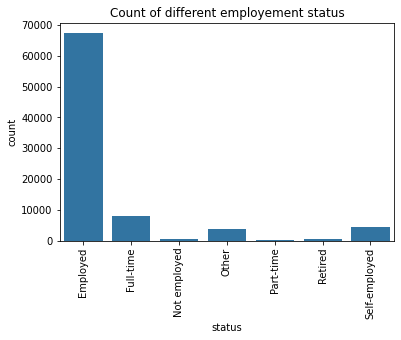

## Loan status

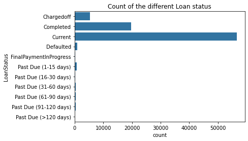

## Stated Monthly Income

> Observation 3:
- the plot is right skewed with a the most frequent monthly income for a borrower is about 5000$.

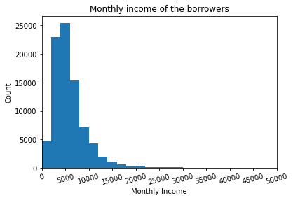